# Sistema de Recomendação de Jogos Baseado em Conteúdo

## O que são sistemas de recomendação baseado em conteúdo?

Os sistemas de recomendação são sistemas de filtragem de informações que personalizam as informações que chegam a um usuário com base em seus interesses e relevância das informações. Os sistemas de recomendação são amplamente usados para recomendar filmes, jogos, artigos, restaurantes, lugares para visitar ou itens para comprar.

[figure not shown]

Um recomendador baseado em conteúdo trabalha com dados que o usuário fornece, seja explicitamente (classificação) ou implicitamente (clicando em um link referente ao item). Com base nesses dados, é gerado um perfil de usuário, o qual é utilizado para fazer sugestões ao usuário.

## Obtenção dos dados via Twitch API

A Twitch API é uma API RESTful que permite aos desenvolvedores criar integrações criativas através dos dados fornecidos pela API.

[figure not shown]

Através da biblioteca requests, é possível fazer requisições GET ou POST e montar o dataset desejado para a aplicação

```python
import numpy as np
import pandas as pd
```

```python
# Informações do usuário na Twitch
client_id = 'your_client_id'
client_secret = 'your_client_secret'
```

```python
# Importa biblioteca requests e faz a requisição na API da Twitch
import requests
client_id = client_id
client_secret = client_secret

body = {
    'client_id': client_id,
    'client_secret': client_secret,
    'grant_type': 'client_credentials'
}

r = requests.post('https://id.twitch.tv/oauth2/token', body)
```

```python
# Obtenção do token de autorização para o usuário
keys = r.json()
```

```python
headers = {
    'Client-ID': client_id,
    'Authorization': 'Bearer ' + keys['access_token']
}

app_token = headers['Authorization']
```

```python
"""Classe IGDB wrapper """

from requests import post
from requests.models import Request, Response

API_URL = "https://api.igdb.com/v4/"

class IGDBWrapper:
    def __init__(self, client_id:str, auth_token:str) -> None:
        self.client_id = client_id
        self.auth_token = auth_token

    def api_request(self, endpoint:str, query:str) -> Response:
        """
        Recebe um endpoint e a APIcalypse query e retorna a resposta API.
        """
        url = IGDBWrapper._build_url(endpoint)
        params = self._compose_request(query)

        response = post(url, **params)
        response.raise_for_status()

        return response

    @staticmethod
    def _build_url(endpoint:str='') -> str:
        return ('%s%s' % (API_URL, endpoint))

    def _compose_request(self, query:str) -> Request:

        request_params = {
            'headers': {
                'Client-ID': self.client_id,
                'Authorization': ('Bearer %s' % (self.auth_token)),
            }
        }

        if isinstance(query, str):
            request_params['data'] = query
            return request_params
```

```python
wrapper = IGDBWrapper(headers['Client-ID'], keys['access_token'])
```

Através da documentação da Twitch API, podemos fazer a requisição das informações necessárias, bem como aplicar filtros para selecionar jogos com características específicas.

Será retornado: Nome, Categoria, Data e Resumo para os jogos lançados após 2014 para PS4 (Código 48) ou XONE (Código 49).

Para mais informações a respeito dos dados e filtros disponíveis, acesse a documentação da API em https://api-docs.igdb.com/#about

```python
def get_game_data(page, page_elements):
    byte_array = wrapper.api_request(
                'games',
                f'fields name, category, first_release_date, summary; offset {page*page_elements}; \
                limit {page_elements}; where (release_dates.platform = (48, 49) & release_dates.y >= 2014);;'
              )
    game_data = byte_array.json()
    return game_data
```

```python
list_of_games = []

flag = 1
page = 0

while flag == 1:
    game_data = get_game_data(page=page, page_elements=500)
    list_of_games.extend(game_data)
    if not game_data:
        flag = 2
    page += 1
```

```python
len(list_of_games)
```

```
8697
```

Para finalizar a montagem do dataset, podemos selecionar apenas os jogos que possuem um resumo associado e também aqueles classificados como jogo principal (categoria = 0), neste caso as expansões são excluídas.

```python
columns=['id', 'name', 'category', 'summary']

ids = []
names = []
summaries = []

for game in list_of_games:
    if 'summary' in game.keys() and game['category'] == 0:
        ids.append(game['id'])
        names.append(game['name'])
        summaries.append(game['summary'])
```

```python
len(ids)
```

```
6212
```

Temos agora o dataset completo com os jogos e o seu respectivo resumo, o qual será utilizado pelo sistema de recomendação

```python
game_dict = {'id': ids, 'name': names, 'summary': summaries}
game_df = pd.DataFrame(game_dict)
```

```python
game_df.head(15)
```

|  | id | name | summary |
| --- | --- | --- | --- |
| 0 | 4 | Thief | There is a rising tide of fear in The City. Ha... |
| 1 | 18 | Max Payne | Max Payne, gritty ex-cop and titular hero of t... |
| 2 | 79 | Stubbs the Zombie in Rebel Without a Pulse | The game is set in a fictional City of the Fut... |
| 3 | 83 | Baldur's Gate: Dark Alliance | Baldur’s Gate™: Dark Alliance™ is a revolution... |
| 4 | 111 | Amnesia: The Dark Descent | Amnesia: The Dark Descent is a survival horror... |
| 5 | 117 | The Last Guardian | In a strange and mystical land, a young boy di... |
| 6 | 120 | Diablo III | The game takes place in Sanctuary, the dark fa... |
| 7 | 134 | Devil May Cry | Legend has it that 2000 years ago in the depth... |
| 8 | 135 | Devil May Cry 2 | Dante is back! Prepare for the next, stylish c... |
| 9 | 148 | Star Wars: Republic Commando | Chaos has erupted throughout the galaxy. As a ... |
| 10 | 152 | Star Wars: Jedi Knight II - Jedi Outcast | In the tradition of the highly acclaimed Star ... |
| 11 | 153 | Star Wars: Jedi Knight - Jedi Academy | Star Wars: Jedi Knight: Jedi Academy, of the h... |
| 12 | 154 | Star Wars: Episode I - Racer | Star Wars: Episode 1 - Racer lets you particip... |
| 13 | 280 | DOOM 3 | A massive demonic invasion has overwhelmed the... |
| 14 | 342 | Duke Nukem 3D | Aliens have landed in futuristic Los Angeles a... |

```python
# remove jogos duplicados
new_game_df = game_df.drop_duplicates(subset='name')
```

```python
# seleciona jogos com 'Kratos' no resumo
new_game_df[new_game_df['summary'].str.contains("Kratos")]
```

|  | id | name | summary |
| --- | --- | --- | --- |
| 1277 | 19560 | God of War | "It is a new beginning for Kratos. Living as a... |
| 3333 | 83778 | God of War: Stone Mason's Edition | Stone Mason Edition Includes:\n\n9" Kratos & A... |
| 3336 | 83824 | God of War: Collector's Edition | The game was released worldwide on April 20, 2... |
| 4124 | 112875 | God of War: Ragnarok | God of War: Ragnarök is the tentative title fo... |
| 4241 | 115067 | God of War: Limited Edition | Limited Edition contains:\n- Steelbook Case\n-... |

```python
# seleciona jogos com 'Ellie' no resumo
new_game_df[new_game_df['summary'].str.contains("Ellie")]
```

|  | id | name | summary |
| --- | --- | --- | --- |
| 1728 | 26192 | The Last of Us Part II | Set 5 years after the events of The Last of Us... |
| 4982 | 130577 | Little Witch in the Woods | In the 'LUCEREIN ORTU', witches live together.... |
| 5207 | 135955 | The Last of Us Part II: Collector's Edition | Set 5 years after the events of The Last of Us... |

```python
# seleciona jogos com 'Batman' no nome
new_game_df[new_game_df['name'].str.contains("Batman")]
```

|  | id | name | summary |
| --- | --- | --- | --- |
| 237 | 5503 | Batman: Arkham Knight | Batman: Arkham Knight brings the award-winning... |
| 372 | 7685 | LEGO Batman 3: Beyond Gotham | In LEGO Batman 3: Beyond Gotham, the Caped Cru... |
| 937 | 14746 | Batman: The Telltale Series | Enter the fractured psyche of Bruce Wayne and ... |
| 1280 | 19563 | Batman: Arkham VR | Your quest to clean up Gotham has only just be... |
| 2647 | 51525 | Batman: The Enemy Within | In this latest chapter, both Bruce Wayne and B... |
| 6110 | 164684 | LEGO Batman 3: Beyond Gotham - Deluxe Edition | The Caped Crusader joins forces with the super... |

```python
# seleciona jogos com 'Fallout' no nome
new_game_df[new_game_df['name'].str.contains("Fallout")]
```

|  | id | name | summary |
| --- | --- | --- | --- |
| 545 | 9630 | Fallout 4 | Bethesda Game Studios, the award-winning creat... |
| 666 | 11119 | Fallout Shelter | Fallout Shelter puts you in control of a state... |
| 2611 | 45130 | Fallout 4: Pip-Boy Edition | Bethesda Game Studios, the award-winning creat... |
| 3013 | 72379 | Fallout 4: Game of The Year Pip-Boy Edition | In addition to including the award-winning ori... |
| 3453 | 89845 | Fallout 4: Gold Bundle | The Fallout 4: Gold Bundle includes the Fallou... |
| 3707 | 103020 | Fallout 76 | Reclamation Day, 2102. Twenty-five years after... |
| 3744 | 103308 | Fallout 76: Tricentennial Edition | Celebrate 300 years of freedom with the all-ne... |
| 5067 | 132975 | Fallout 76: Wastelanders - Deluxe Edition | Bethesda Game Studios welcome you to Fallout 7... |
| 5537 | 141647 | Fallout 76: Steel Dawn - Deluxe Edition | Steel Dawn is the first chapter in the new Bro... |

É interessante salvar como .csv para não precisar chamar mais a API da Twitch, o que leva cerca de 5 minutos com o filtro atual. Sendo assim, o dataframe é exportado para 'twitch_game_data.csv' e lido pelo Pandas.

```python
new_game_df.to_csv('twitch_game_data.csv')
```

```python
game_df = pd.read_csv('twitch_game_data.csv')
game_df = game_df.drop(columns='Unnamed: 0')
```

```python
game_df.head(20)
```

|  | id | name | summary |
| --- | --- | --- | --- |
| 0 | 4 | Thief | There is a rising tide of fear in The City. Ha... |
| 1 | 18 | Max Payne | Max Payne, gritty ex-cop and titular hero of t... |
| 2 | 79 | Stubbs the Zombie in Rebel Without a Pulse | The game is set in a fictional City of the Fut... |
| 3 | 83 | Baldur's Gate: Dark Alliance | Baldur’s Gate™: Dark Alliance™ is a revolution... |
| 4 | 111 | Amnesia: The Dark Descent | Amnesia: The Dark Descent is a survival horror... |
| 5 | 117 | The Last Guardian | In a strange and mystical land, a young boy di... |
| 6 | 120 | Diablo III | The game takes place in Sanctuary, the dark fa... |
| 7 | 134 | Devil May Cry | Legend has it that 2000 years ago in the depth... |
| 8 | 135 | Devil May Cry 2 | Dante is back! Prepare for the next, stylish c... |
| 9 | 148 | Star Wars: Republic Commando | Chaos has erupted throughout the galaxy. As a ... |
| 10 | 152 | Star Wars: Jedi Knight II - Jedi Outcast | In the tradition of the highly acclaimed Star ... |
| 11 | 153 | Star Wars: Jedi Knight - Jedi Academy | Star Wars: Jedi Knight: Jedi Academy, of the h... |
| 12 | 154 | Star Wars: Episode I - Racer | Star Wars: Episode 1 - Racer lets you particip... |
| 13 | 280 | DOOM 3 | A massive demonic invasion has overwhelmed the... |
| 14 | 342 | Duke Nukem 3D | Aliens have landed in futuristic Los Angeles a... |
| 15 | 359 | Final Fantasy XV | Take the journey, now in ultimate quality. Boa... |
| 16 | 386 | Final Fantasy XIV Online | Take part in an epic and ever-changing FINAL F... |
| 17 | 427 | Final Fantasy VII | Final Fantasy VII is the seventh main installm... |
| 18 | 493 | Heavy Rain | Heavy Rain is a cinematic psychological thrill... |
| 19 | 496 | Dead Rising 2 | As Chuck Greene, you have 72 hours to save you... |

## Sistema de Recomendação Baseado em Conteúdo

### Passo 1) Criação de um Vetorizador TF-IDF

O algoritmo TF *IDF é usado para pesar uma palavra-chave em qualquer documento e atribuir a importância a essa palavra-chave com base no número de vezes que ela aparece no documento. Simplificando, quanto mais alto o TF* IDF (peso), mais raro e importante o termo e vice-versa.

Cada palavra ou termo tem sua respectiva pontuação TF e IDF, sendo eles representados

- O TF (frequência do termo) de uma palavra é o número de vezes que ela aparece em um documento ou descrição de item.
- O IDF (frequência inversa do documento) de uma palavra é a medida de quão significativo esse termo é em relação aos outros jogos disponíveis

Em Python, o scikit-learn oferece um vetorizador TF-IDF pré-construído que calcula a pontuação TF-IDF para a descrição de cada item, palavra por palavra.

```python
from sklearn.feature_extraction.text import TfidfVectorizer
from sklearn.metrics.pairwise import linear_kernel
```

```python
tf = TfidfVectorizer(analyzer='word', ngram_range=(1, 3), min_df=0, stop_words='english')
tfidf_matrix = tf.fit_transform(game_df['summary'])
```

```python
tfidf_matrix
```

```
<6201x428419 sparse matrix of type '<class 'numpy.float64'>'
	with 691220 stored elements in Compressed Sparse Row format>
```

A tfidf_matrix é a matriz que contém cada palavra e sua pontuação TF-IDF em relação a cada jogo neste caso. Além disso, palavras irrelevantes como 'uma', 'é', 'o' não agregam valor para a descrição do jogo, portanto, são ignoradas pelo sistema.

### Passo 2) Similaridade por Cosseno

A similaridade por cosseno é uma medida entre dois vetores num espaço vetorial que avalia o valor do cosseno do ângulo compreendido entre eles. Portanto pode-se aplicar a similaridade por cosseno para de estabelecer uma métrica de semelhança entre textos de itens ou documentos.

A razão final por trás do uso do cosseno é que o valor do cosseno aumentará conforme o ângulo entre os vetores diminui, o que indica maior similaridade.

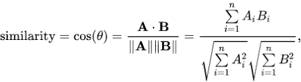

Agora, com a semelhança de cosseno de cada item com todos os outros itens do conjunto de dados, os ordenamos de acordo com sua semelhança com o respectivo item, e armazenamos os valores nos resultados.

```python
cosine_similarities = linear_kernel(tfidf_matrix, tfidf_matrix)
results = {}

for idx, row in game_df.iterrows():
   similar_indices = cosine_similarities[idx].argsort()[:-100:-1]
   similar_items = [(cosine_similarities[idx][i], game_df['id'][i]) for i in similar_indices]
   results[row['id']] = similar_items[1:]
```

### Passo 3) Realizando Recomendações

Então aqui vem a parte em que finalmente conseguimos ver o sistema de recomendação em ação.

[figure not shown]

```python
# Retorna o nome do jogo dado um item_id
def item_name(id):
    return game_df.loc[game_df['id'] == id]['name'].values[0]
```

```python
# Seleciona os jogos mais similares ao jogo desejado
def recommend(item_id, num):
    print("Recomendando " + str(num) + " produtos simulares a " + item_name(item_id) + "...")
    print("-------")
    recs = results[item_id][:num]
    for rec in recs:
        print(f"Recomendado: {item_name(rec[1])}")
```

Aqui, apenas inserimos um item_id e o número de recomendações desejadas.

A função 'recommend' coleta os resultados dos itens mais similares correspondentes a esse item_id e apresenta as recomendações na tela.

```python
desired_item_name = 'God of War'
desired_item_id = game_df.loc[game_df['name'] == desired_item_name]['id'].values[0]

recommend(item_id=desired_item_id, num=20)
```

```
Recomendando 20 produtos simulares a God of War...
-------
Recomendado: God of War: Limited Edition
Recomendado: God of War: Stone Mason's Edition
Recomendado: God of War: Collector's Edition
Recomendado: God of War: Ragnarok
Recomendado: Jotun: Valhalla Edition
Recomendado: Kingdom: New Lands
Recomendado: Die for Valhalla!
Recomendado: The Colonists
Recomendado: Shadow Warrior Collection
Recomendado: Gods Will Fall: Valiant Edition
Recomendado: Mass Effect: Andromeda
Recomendado: Immortals Fenyx Rising: Limited Edition
Recomendado: Outbreak Bundle
Recomendado: Fear Effect Sedna
Recomendado: Northgard
Recomendado: Remothered: Broken Porcelain
Recomendado: Cris Tales
Recomendado: Eternity: The Last Unicorn
Recomendado: Eldest Souls
Recomendado: CARAVAN STORIES
```

```python
desired_item_name = 'Ghost of Tsushima'
desired_item_id = game_df.loc[game_df['name'] == desired_item_name]['id'].values[0]

recommend(item_id=desired_item_id, num=20)
```

```
Recomendando 20 produtos simulares a Ghost of Tsushima...
-------
Recomendado: Samurai Warriors 5: Treasure Box
Recomendado: Samurai Warriors 4-II
Recomendado: Samurai Warriors 5
Recomendado: SAMURAI SHODOWN
Recomendado: Ghost of Tsushima: Digital Deluxe Edition
Recomendado: Seasons of the Samurai
Recomendado: Samurai Warriors 4
Recomendado: Reborn: A Samurai Awakens
Recomendado: Warriors Orochi 4
Recomendado: The American Dream
Recomendado: Samurai Warriors 4: Empires
Recomendado: Samurai Warriors 5: Ikkitousen Box
Recomendado: Ghost of Tsushima: Collector's Edition
Recomendado: Nioh
Recomendado: Element Space
Recomendado: Phoenix Point: Year One Edition
Recomendado: Samurai Jack: Battle Through Time
Recomendado: Skulls of the Shogun
Recomendado: Gutwhale
Recomendado: Tom Clancy's Ghost Recon: Wildlands - Ultimate Edition
```

```python
desired_item_name = 'Batman: Arkham Knight'
desired_item_id = game_df.loc[game_df['name'] == desired_item_name]['id'].values[0]

recommend(item_id=desired_item_id, num=20)
```

```
Recomendando 20 produtos simulares a Batman: Arkham Knight...
-------
Recomendado: Batman: Arkham VR
Recomendado: Batman: The Enemy Within
Recomendado: Gotham Knights
Recomendado: Arkham Horror: Mother's Embrace
Recomendado: DC Universe Online
Recomendado: Middle-earth: Shadow of Mordor
Recomendado: LEGO Batman 3: Beyond Gotham
Recomendado: Batman: The Telltale Series
Recomendado: Horned Knight
Recomendado: Shovel Knight
Recomendado: The Witch and the Hundred Knight 2
Recomendado: Halo 4
Recomendado: Payday 2: Crimewave Edition
Recomendado: Tetris Ultimate
Recomendado: Sleeping Dogs: Definitive Edition
Recomendado: Star Wars: Jedi Knight - Jedi Academy
Recomendado: Life is Strange 2
Recomendado: HITMAN 3
Recomendado: Knight Squad
Recomendado: Nidhogg 2
```